# Preliminary Exploratory Data Analysis

Nicholas Neo

17 July 2020

## Synopsis

This is the Milestone Report for the Capstone Course of the Data Science Specialisation

## Goal of this Report

**Goal**  
1. Explain the exploratory analysis for the SwiftKey dataset and the goal for the eventual app and algorithm.  
2. Explain only the major features of the data that was identified.  
3. Briefly summarise the plans for creating the prediction algorithm and Shiny app in a way that would be understandable to a non-data scientist manager.  
4. Make use of tables and plots to illustrate important summaries of the datasets.

## Motivation of this Report

**Motivation**  
1. Demonstrate that the data had been downloaded successfully.  
2. Create a basic report of summary statistics about the datasets.  
3. Report any interesting findings that was amassed so far.  
4. Get feedback on the plans for creating a prediction algorithm and Shiny app.

## About the SwiftKey Dataset

For this report, we will be only do exploratory analysis at the **English dataset** which consist of:  
1. blog posts (en_US.blogs.txt)  
2. news (en_US.news.txt)  
3. twitter tweets (en_US.twitter.txt)

**Load the English dataset**  
*Note: the datasets were already downloaded beforehand and the root folder of the datasets (Cousera-SwiftKey) resides in the same directory as this markdown file.*

```r
blog_data<-readLines("./Coursera-SwiftKey/final/en_US/en_US.blogs.txt", skipNul = TRUE, warn= FALSE)
news_data<-readLines("./Coursera-SwiftKey/final/en_US/en_US.news.txt", skipNul = TRUE, warn=FALSE)
twitter_data<-readLines("./Coursera-SwiftKey/final/en_US/en_US.twitter.txt", skipNul = TRUE, warn=FALSE)
```

**Size of each dataset**  
*divide by 2^20 to convert bytes to megabytes*

```r
blog_data_size<-file.info("./Coursera-SwiftKey/final/en_US/en_US.blogs.txt")$size/2^20
news_data_size<-file.info("./Coursera-SwiftKey/final/en_US/en_US.news.txt")$size/2^20
twitter_data_size<-file.info("./Coursera-SwiftKey/final/en_US/en_US.twitter.txt")$size/2^20

# fit the size data into a dataframe to see the sizes clearer
dataset_EN<-c(blog_data_size,news_data_size,twitter_data_size)
df_size<-data.frame(dataset_EN)
names(df_size)[1] <-"MB"
row.names(df_size) <- c("Blog Posts", "News", "Twitter Tweets")
round(df_size,2)
```

```
##                    MB
## Blog Posts     200.42
## News           196.28
## Twitter Tweets 159.36
```

**Summary of each dataset**  
*To get a rough sense of how each of the 3 English data look like*

```r
summary(blog_data)
```

```
##    Length     Class      Mode
##    899288 character character
```

```r
head(blog_data,3)
```

```
## [1] "In the years thereafter, most of the Oil fields and platforms were named after pagan â\200œgodsâ\200\235."
## [2] "We love you Mr. Brown."
## [3] "Chad has been awesome with the kids and holding down the fort while I work later than usual! The kids have been busy together playing Skylander on the XBox together, after Kyan cashed in his $$$ from his piggy bank. He wanted that game so bad and used his gift card from his birthday he has b…
```

```r
summary(news_data)
```

```
##    Length     Class      Mode
##     77259 character character
```

```r
head(news_data,3)
```

```
## [1] "He wasn't home alone, apparently."
## [2] "The St. Louis plant had to close. It would die of old age. Workers had been making cars there since the onset of mass automotive production in the 1920s."
## [3] "WSU's plans quickly became a hot topic on local online sites. Though most people applauded plans for the new biomedical center, many deplored the potential loss of the building."
```

```r
summary(twitter_data)
```

```
##    Length     Class      Mode
##   2360148 character character
```

```r
head(twitter_data,3)
```

```
## [1] "How are you? Btw thanks for the RT. You gonna be in DC anytime soon? Love to see you. Been way, way too long."
## [2] "When you meet someone special... you'll know. Your heart will beat more rapidly and you'll smile for no reason."
## [3] "they've decided its more fun if I don't."
```

**Count number of lines and number of words in each of the dataset**  
*Line Count*

```r
blog_data_lc<-length(blog_data)
news_data_lc<-length(news_data)
twitter_data_lc<-length(twitter_data)
dataset_lc <-c(blog_data_lc,news_data_lc, twitter_data_lc)
dataset_lc_df <-data.frame(dataset_lc)
names(dataset_lc_df)[1] <-"Line Count"
# fit the size data into a dataframe to see the line count clearer
row.names(dataset_lc_df) <- c("Blog Posts", "News", "Twitter Tweets")
dataset_lc_df
```

```
##                Line Count
## Blog Posts         899288
## News                77259
## Twitter Tweets    2360148
```

*Word Count*

```r
# import ngram library to count number of words
library(ngram)

blog_data_wc <-wordcount(blog_data)
news_data_wc <-wordcount(news_data)
twitter_data_wc <-wordcount(twitter_data)
dataset_wc <-c(blog_data_wc,news_data_wc, twitter_data_wc)
dataset_wc_df <-data.frame(dataset_wc)
names(dataset_wc_df)[1] <-"Word Count"
row.names(dataset_wc_df) <- c("Blog Posts", "News", "Twitter Tweets")
dataset_wc_df
```

```
##                Word Count
## Blog Posts       37334131
## News              2643969
## Twitter Tweets   30373583
```

## Subsetting of data

Since the data size for all 3 files are relatively large, we will just sample one subset each from the 3 datasets for the exploratory analysis.  
*We will just use 1% of the data from each of the 3 sets to form the subsets which in turn combine it into a dataframe.*

```r
SAMPLE_SIZE <- 0.01
blog_index <- sample(seq_len(blog_data_lc),blog_data_lc*SAMPLE_SIZE)
news_index <- sample(seq_len(news_data_lc),news_data_lc*SAMPLE_SIZE)
twitter_index <- sample(seq_len(twitter_data_lc),twitter_data_lc*SAMPLE_SIZE)
blog_data_subset <- blog_data[blog_index[]]
news_data_subset <- news_data[news_index[]]
twitter_data_subset <- twitter_data[twitter_index[]]
```

**Delete all saved dataframe that are of no use anymore**  
*This is to save space for more memory intensive variables*

```r
rm(list= ls()[!(ls() %in% c('blog_data_subset','news_data_subset','twitter_data_subset'))])
```

## Combining the datasets (subsets) into one dataset

Using the ‘tm’ library from R, we will create a corpus from the dataset subsets.  
**We will convert**  
- all alphabets into lowercase  
**And omit**  
- non-ASCII character data  
- extra white spaces  
- punctuation marks  
- numeric values  
*These steps are necessary as we want to remove all the characters that are not useful for the training of the data and to reassure that lower and upper case representation of the words are the same.*

```r
library(tm)
library(NLP)
main_df <- VCorpus(VectorSource(c(blog_data_subset, news_data_subset, twitter_data_subset)),readerControl=list(reader=readPlain,language="en"))
main_df <- Corpus(VectorSource(sapply(main_df, function(row) iconv(row, "latin1", "ASCII", sub=""))))
main_df <- tm_map(main_df, content_transformer(tolower))
main_df <- tm_map(main_df, stripWhitespace)
main_df <- tm_map(main_df, removePunctuation)
main_df <- tm_map(main_df, removeNumbers)
main_df <- tm_map(main_df, PlainTextDocument)
main_df <- Corpus(VectorSource(main_df))
#head(main_df,5)
```

## Building a unigram

*We will build the unigram from the text corpus main_df using RWeka to see the most common word in the data*

```r
# import RWeka library
library(RWeka)
uni <- function(x) NGramTokenizer(x,Weka_control(min=1,max=1))
uni_table <- TermDocumentMatrix(main_df, control=list(tokenize=uni))
uni_corpus <- findFreqTerms(uni_table,lowfreq = 2000)
uni_corpus_count <- rowSums(as.matrix(uni_table[uni_corpus,]))
uni_corpus_df <- data.frame(Word=names(uni_corpus_count),frequency=uni_corpus_count)
# get counts of words in descending order
uni_corpus_sorted <- uni_corpus_df[order(-uni_corpus_df$frequency),]
# get top 10 words with highest frequency
head(uni_corpus_sorted,10)
```

```
##      Word frequency
## the   the     27648
## and   and     15164
## you   you      7500
## for   for      7411
## that that      6777
## with with      4585
## was   was      3958
## have have      3745
## this this      3718
## are   are      3310
```

## Interesting findings (so far…)

From the text, you can see words with high frequencies (most common words) are usually a pronoun and stopwords, which does not add meaning to the sentence. As such, we will need to remove these stopwords so that our dataset only contains meaningful words that can be useful for the prediction later on. Removing stopwords also increases the accuracy of the prediction as there will be less variant of the combinations of the words.

**Delete all saved dataframe that are of no use anymore**  
*This is to save space for more memory intensive variables*

```r
rm(list= ls()[!(ls() %in% c('main_df'))])
```

## Removal of Stopwords

*Remove all stopwords*

```r
main_df <- tm_map(main_df, removeWords, stopwords("english"))
```

## Building Uni-gram

**Load RWeka**

```r
library(RWeka)
```

**uni-gram**

```r
uni <- function(x) NGramTokenizer(x,Weka_control(min=1,max=1))
uni_table <- TermDocumentMatrix(main_df, control=list(tokenize=uni))
uni_corpus <- findFreqTerms(uni_table,lowfreq = 500)
uni_corpus_count <- rowSums(as.matrix(uni_table[uni_corpus,]))
uni_corpus_df <- data.frame(Word=names(uni_corpus_count),frequency=uni_corpus_count)
# get counts of words in descending order
uni_corpus_sorted <- uni_corpus_df[order(-uni_corpus_df$frequency),]
# get top 10 words with highest frequency
head(uni_corpus_sorted,15)
```

```
##          Word frequency
## like     like      2193
## just     just      2106
## will     will      2098
## one       one      1919
## can       can      1789
## get       get      1655
## time     time      1475
## love     love      1405
## dont     dont      1367
## know     know      1335
## good     good      1238
## new       new      1219
## day       day      1211
## see       see      1109
## people people      1077
```

## Graph

*Plot the histogram of the top most 15 common word found*

```r
library(slam)
```

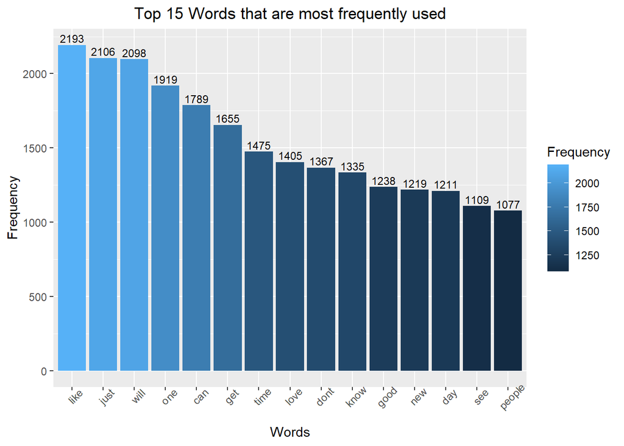

```r
library(ggplot2)
main_corpus <-TermDocumentMatrix(main_df,control=list(minWordLength=1))
wordFrequency <-rowapply_simple_triplet_matrix(main_corpus,sum)
wordFrequency <-wordFrequency[order(wordFrequency,decreasing=T)]
word_top15 <-as.data.frame(wordFrequency[1:15])

#data$carb <- factor(data$carb, levels = data$carb[order(-data$mpg)])
word_top15 <-data.frame(Words = row.names(word_top15),word_top15)
names(word_top15)[2] = "Frequency"
word_top15_plot = ggplot(data=word_top15, aes(x=reorder(Words,-Frequency), y=Frequency, fill=Frequency)) + geom_bar(stat="identity") + theme(axis.text.x=element_text(angle=45)) + geom_text(aes(label = Frequency ), vjust = -0.30, size = 3)
word_top15_plot + ggtitle("Top 15 Words that are most frequently used") + theme(plot.title = element_text(hjust = 0.5)) + labs(y="Frequency", x = "Words")
```

## Project Plan

We can use the model that we have analysed and train to generate the next possible word given an input sentence by the user. With the term frequency–inverse document frequency (TF-IDF) analysis and analysing of the uni,bi and tri-gram, predicting the next word given an input sentence might be possible and this sort of mimic the real Recurrent Neural Network (RNN) in the deep learning literature. This is also quite a scaled down version of what SwiftKey is doing –> text prediction. We will then incorporate this idea and deploy it into Shiny.io which is a webpage that will serve the user. It allows the user to input an incomplete sentence and then expect a 1-word output based on their input.